# toothfish project

RF

```r
library(tidyverse)
library(mizer)
```

I need to make a mizer model out of a bunch of data

# The data I have:

```r
load("size_spec_inputs.RData")
```

This loads 3 var: ll_trends, rsts_m1_coocur, rsts_trends

ll_trends is the longline fisheries fishing only toothfish

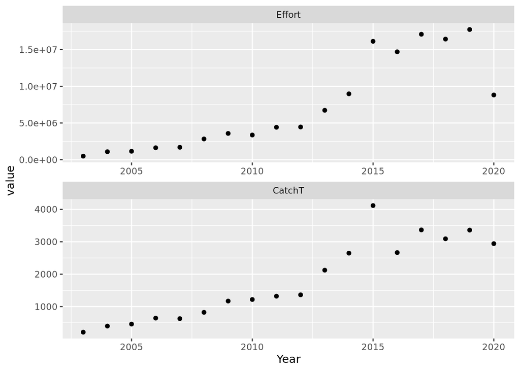

```r
view(ll_trends)

plot_dat <- reshape2::melt(ll_trends, "Year")

ggplot(plot_dat, aes(x = Year, y = value)) +
  geom_point() +
  facet_wrap(~variable, nrow = 2, scales = "free")
```

The co-occurence of sites from the survey

```r
view(rsts_m1_cooccur)
```

Biomass of species per year from trawls

```r
view(rsts_trends)
```

# Creating the species_params df

Need w_inf for that

## Summary of species

### Dissostichus eleginoides

https://www.fishbase.se/summary/Dissostichus-eleginoides.html

Maturity: Lm 49.0, range 38 - 60 cm

Max length : 215 cm TL male/unsexed

common length : 70.0 cm TL male/unsexed

max. published weight: 9.6 kg

max. reported age: 31 years

a=0.00631

b=3.15

Biology: At 12-15 cm TL, semi-pelagic juveniles become demersal at 150-400 m depth. Adults migrate to deeper habitats at depths greater than 1,000 m. Utilized as food fish.

### Champsocephalus gunnari

https://www.fishbase.se/summary/Champsocephalus-gunnari.html

Maturity: Lm 26.0, range 21 - 32 cm

Max length : 66.0 cm TL male/unsexed

common length : 35.0 cm TL male/unsexed

a=0.00120

b=3.47

max. published weight: 2.0 kg

Biology: Feed mainly on krill and mysids. Spawn in autumn and winter. Synchronous spawner. Larval pelagic phase is long. Utilized as a food fish.

### Channichthys rhinoceratus

https://www.fishbase.se/summary/Channichthys-rhinoceratus.html

Maturity: Lm ? range ? - ? cm

Max length : 60.0 cm TL male/unsexed

common length : 40.0 cm TL male/unsexed

max. published weight: 500.00 g

a=0.00129

b=3.46

Biology: Adults are found from near shore to farther than 750 m. Feed mainly on fishes and occasionally on algae.

### Lepidonotothen squamifrons

https://www.fishbase.se/summary/Lepidonotothen-squamifrons.html

Maturity: Lm 27.3, range 19 - 36 cm

Max length : 55.0 cm TL male/unsexed

common length : 35.0 cm TL male/unsexed

max. reported age: 19 years

a=0.00468

b=3.24

Feeds chiefly on macrozooplankton (mainly crustaceans, cnidarians and salps) and midwater fishes.

### Macrourus

Biology: Only have the genus, don’t know about the species, only that there are 2. Need to check the excel file

### Bathyraja eatonii

https://www.fishbase.se/summary/Bathyraja-eatonii.html

Maturity: Lm ? range ? - ? cm

Max length : 100.0 cm TL male/unsexed

a=0.00513

b=3.12

Biology: Oviparous. Eggs have horn-like projections on the shell.

### Bathyraja irrasa

https://www.fishbase.se/summary/Bathyraja-irrasa.html

Maturity: Lm ? range ? - ? cm

Max length : 120 cm TL male/unsexed

a=0.00513

b=3.12

Biology: Oviparous. Distinct pairing with embrace. Young may tend to follow large objects, such as their mother. Eggs are oblong capsules with stiff pointed horns at the corners deposited in sandy or muddy flats. Egg capsules are 11.38 cm long and 7.36 cm wide.

### Gobionotothen acuta

https://www.fishbase.se/summary/Gobionotothen-acuta.html

Maturity: Lm ? range ? - ? cm

Max length : 35.0 cm SL male/unsexed

a=0.00603

b=3.25

Biology: Found in fairly shallow water

### Bathyraja murrayi

https://www.fishbase.se/summary/Bathyraja-murrayi.html

Maturity: Lm ? range ? - ? cm

Max length : 60.0 cm TL male/unsexed

a=0.00513

b=3.12

Oviparous. Distinct pairing with embrace. Young may tend to follow large objects, such as their mother. Eggs are oblong capsules with stiff pointed horns at the corners deposited in sandy or muddy flats. Egg capsules are 6.0 cm long and 3.4 cm wide. Frequently taken in commercial bottom hauls but not much utilized because of its small size

```r
species_df <- data.frame("species" = colnames(rsts_trends)[-(1:2)],
                         "l_inf" = c(215) )

params <- newMultispeciesParams(species_params = species_df)
```